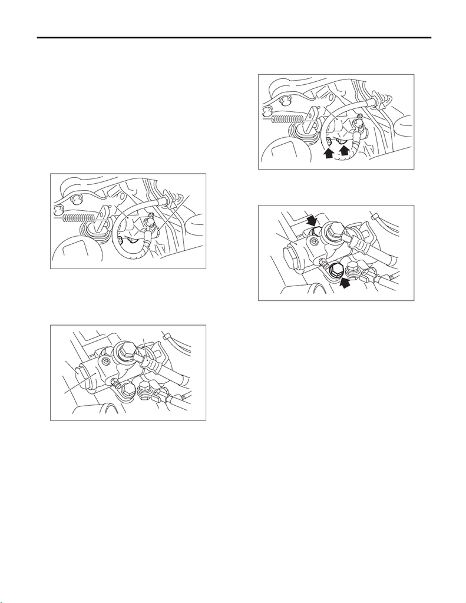

Operating Cylinder

CLUTCH SYSTEM

5. Operating Cylinder

A: REMOVAL

1) Remove the intercooler. <Ref. to IN(STI)-13,

REMOVAL, Intercooler.> <Ref. to IN(w/o STI)-38,

REMOVAL, Intercooler.>

2) Disconnect the clutch hose from the operating

cylinder.

CAUTION:

• Cover the hose joint to prevent the clutch flu-

id from flowing out.

• Do not loosen or remove the cap bolts.

• STI model

• Except for STI model

3) Remove the operating cylinder from the trans-

mission.

• STI model

• Except for STI model

(A) Clutch hose

(B) Operating cylinder

(C) Cap bolt

(A) Clutch hose

(B) Operating cylinder

(C) Cap bolt

(B)

(A)

(C)

CL-00796

(A)

(B)

(C)

(A) Operating cylinder

(A) Operating cylinder

(A)

CL-00419

CL-00823

(A)

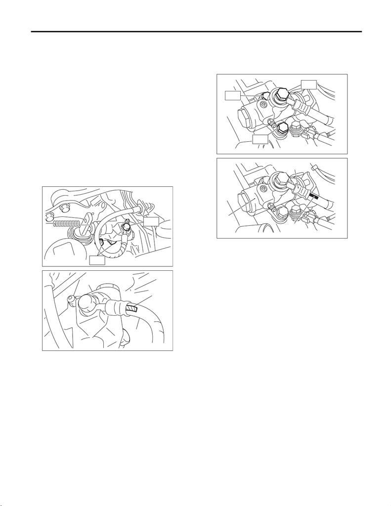

Operating Cylinder

CLUTCH SYSTEM

B: INSTALLATION

1) Install in the reverse order of removal.

NOTE:

• Use a new washer.

• Before installing the operating cylinder, apply

grease to the contact point of the release lever and

operating cylinder.

Grease

NICHIMOLY N-130 or equivalent

• Be sure to install the clutch hose with the mark

side facing upward.

• Be careful not to twist the clutch hose during in-

stallation.

• STI model

Tightening torque:

T1: 18 N·m (1.8 kgf-m, 13.3 ft-lb)

T2: 41 N·m (4.2 kgf-m, 30.2 ft-lb)

• Except for STI model

Tightening torque:

T1: 18 N·m (1.8 kgf-m, 13.3 ft-lb)

T2: 37 N·m (3.8 kgf-m, 27.3 ft-lb)

2) After bleeding air from the operating cylinder,

ensure that the clutch operates properly.

<Ref. to CL-29, Clutch Fluid Air Bleeding.>

(A) Mark

(B) Clutch hose

(C) Operating cylinder

T2

T1

CL-00802

(A)

(B)

(C)

(A) Clutch hose

(B) Operating cylinder

(C) Mark

CL-00709

T1

T2

T2

CL-00743

(A)

(B)

(C)

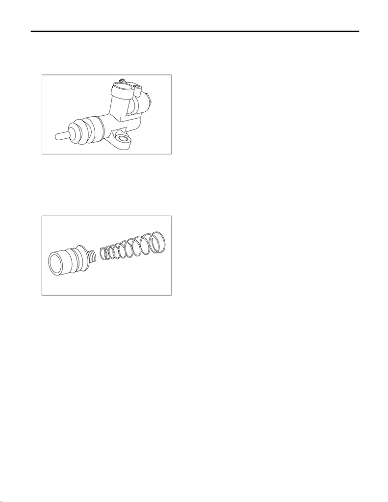

Operating Cylinder

CLUTCH SYSTEM

C: DISASSEMBLY

CAUTION:

Do not disassemble the STI model.

1) Remove the boot and push rod.

2) Apply compressed air through clutch hose at-

tachment hole.

NOTE:

Face the piston hole down and place a piece of

wood underneath to prevent the piston from pop-

ping out.

3) Separate the piston and piston spring.

D: ASSEMBLY

NOTE:

During assembly, apply hydraulic oil to all parts.

Recommended clutch fluid:

New FMVSS No. 116 DOT3 or DOT4

1) Install the piston spring onto the piston.

2) Insert piston into the operating cylinder.

3) Install push rod to the boot.

4) Install boot and push rod to the operating cylin-

der.

E: INSPECTION

1) Check that the operating cylinder is not dam-

aged. If operating cylinder is damaged, replace it.

2) Check the operating cylinder for fluid leakage or

damage on the boot. Replace the operating cylin-

der if leaks or damages are noted.

CL-00716

CL-00717